# Project : Investigate Movie Data

- Introduction
- Data Wrangling
- Exploratory Data Analysis
- Conclusions

<a id = "intro"></a>

## Introduction

> For this **Project** We have chosen the *TMDb data* or *The Movies Database* obtained from *Kaggle*. This data set contains information about 10,000 movies including their User ratings and revenue.

> The questions that we will attempt to answer are :

```
1.  which kind of movies earn the most?
2.  Does the runtime affect the popularity of the movie?
3.  Does popularity affect vote count in a considerable way?
```

> We will now import the necessary packages and load the data

```python
import pandas as pd
import numpy as np
% matplotlib inline

df = pd.read_csv('tmdb-movies.csv')
```

<a id = "wrangling"></a>

## Data Wrangling

> We will now check if there is any missing data in the data file

```python
df.info()
```

```
<class 'pandas.core.frame.DataFrame'>
RangeIndex: 10866 entries, 0 to 10865
Data columns (total 21 columns):
id                      10866 non-null int64
imdb_id                 10856 non-null object
popularity              10866 non-null float64
budget                  10866 non-null int64
revenue                 10866 non-null int64
original_title          10866 non-null object
cast                    10790 non-null object
homepage                2936 non-null object
director                10822 non-null object
tagline                 8042 non-null object
keywords                9373 non-null object
overview                10862 non-null object
runtime                 10866 non-null int64
genres                  10843 non-null object
production_companies    9836 non-null object
release_date            10866 non-null object
vote_count              10866 non-null int64
vote_average            10866 non-null float64
release_year            10866 non-null int64
budget_adj              10866 non-null float64
revenue_adj             10866 non-null float64
dtypes: float64(4), int64(6), object(11)
memory usage: 1.7+ MB
```

> We can clearly see that there are many columns with missing data. The number of values should be 10866 for every column yet there are some which have less than the required 10866 values.

> We can also see that the coulmns with missing data are of type object. If these are of type string then there is no need to fill the missing places.

```python
# to fill the empty places
df.fillna(df.mean(), inplace= True)
```

```python
# to check that there are no empty places left
df.info()
```

```
<class 'pandas.core.frame.DataFrame'>
RangeIndex: 10866 entries, 0 to 10865
Data columns (total 21 columns):
id                      10866 non-null int64
imdb_id                 10856 non-null object
popularity              10866 non-null float64
budget                  10866 non-null int64
revenue                 10866 non-null int64
original_title          10866 non-null object
cast                    10790 non-null object
homepage                2936 non-null object
director                10822 non-null object
tagline                 8042 non-null object
keywords                9373 non-null object
overview                10862 non-null object
runtime                 10866 non-null int64
genres                  10843 non-null object
production_companies    9836 non-null object
release_date            10866 non-null object
vote_count              10866 non-null int64
vote_average            10866 non-null float64
release_year            10866 non-null int64
budget_adj              10866 non-null float64
revenue_adj             10866 non-null float64
dtypes: float64(4), int64(6), object(11)
memory usage: 1.7+ MB
```

```python
#check for duplicates in data
sum(df.duplicated())
```

```
1
```

```python
# to remove the duplicate from the file
df.drop_duplicates(inplace=True)
```

```python
# to check that the duplicate has been removed
sum(df.duplicated())
```

```
0
```

```python
df.info()
```

```
<class 'pandas.core.frame.DataFrame'>
Int64Index: 10865 entries, 0 to 10865
Data columns (total 21 columns):
id                      10865 non-null int64
imdb_id                 10855 non-null object
popularity              10865 non-null float64
budget                  10865 non-null int64
revenue                 10865 non-null int64
original_title          10865 non-null object
cast                    10789 non-null object
homepage                2936 non-null object
director                10821 non-null object
tagline                 8041 non-null object
keywords                9372 non-null object
overview                10861 non-null object
runtime                 10865 non-null int64
genres                  10842 non-null object
production_companies    9835 non-null object
release_date            10865 non-null object
vote_count              10865 non-null int64
vote_average            10865 non-null float64
release_year            10865 non-null int64
budget_adj              10865 non-null float64
revenue_adj             10865 non-null float64
dtypes: float64(4), int64(6), object(11)
memory usage: 1.8+ MB
```

> After removal of the duplicate file the total number of rows should be 10865 but as we can clearly see there are still some columns having less than 10865 rows in them. Because these columns have string type data we cannot fill the empty places in these columns.

> We have finished **Wrangling** or **Cleaning** the data.

<a id = "eda"></a>

## Exploratory Data Analysis

> We will now check how different column-entities affect other column-entities with the use of graphs.

```python
df.describe()
```

[output not shown]

```python
df['revenue'].max()
```

```
2781505847
```

```python
import numpy as np
df.loc[df['revenue'].idxmax()]
```

```
id                                                                  19995
imdb_id                                                         tt0499549
popularity                                                        9.43277
budget                                                          237000000
revenue                                                        2781505847
original_title                                                     Avatar
cast                    Sam Worthington|Zoe Saldana|Sigourney Weaver|S...
homepage                                      http://www.avatarmovie.com/
director                                                    James Cameron
tagline                                       Enter the World of Pandora.
keywords                culture clash|future|space war|space colony|so...
overview                In the 22nd century, a paraplegic Marine is di...
runtime                                                               162
genres                           Action|Adventure|Fantasy|Science Fiction
production_companies    Ingenious Film Partners|Twentieth Century Fox ...
release_date                                                     12/10/09
vote_count                                                           8458
vote_average                                                          7.1
release_year                                                         2009
budget_adj                                                    2.40887e+08
revenue_adj                                                   2.82712e+09
Name: 1386, dtype: object
```

> Now that we have found the movie with the highest revenue we will try to discover the factors that affect the revenue of a movie.

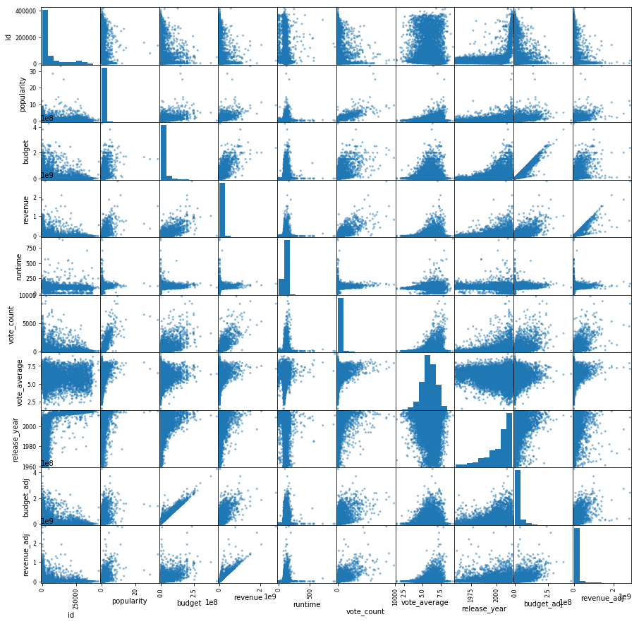

```python
pd.plotting.scatter_matrix(df, figsize=(15, 15));
```

```python
df['keywords'].value_counts()
```

```
woman director                                                        134
independent film                                                       82
sport                                                                  25
suspense                                                               24
musical                                                                24
duringcreditsstinger                                                   24
holiday                                                                16
stand-up|stand up comedy                                               16
biography                                                              15
independent film|woman director                                        13
stand up comedy                                                         9
based on novel                                                          7
dystopia                                                                7
christmas                                                               7
holiday|christmas                                                       7
found footage                                                           7
sequel                                                                  6
aftercreditsstinger                                                     6
cop|new england|jesse stone                                             5
aftercreditsstinger|duringcreditsstinger                                5
crime solving                                                           5
based on video game                                                     4
independent film|duringcreditsstinger                                   4
werewolf                                                                4
dinosaur                                                                4
zombies                                                                 4
possession                                                              4
baseball|sport                                                          4
stand-up                                                                4
martial arts                                                            3
                                                                     ...
paranoia|garbage|psychopath|vacation|black comedy                       1
expedition|pilot|survival|sled dogs|seal                                1
slacker|basement|destiny|glue|stoner                                    1
pixar animated short|tow truck|police car|cgi animation                 1
martial arts|chinese|martial arts master|fighting|ancient china         1
u.s. president|president elections|comedian                             1
brother brother relationship|corruption|police|stripper|love            1
big family|new job|aspiring actor|smart kid                             1
american football|adoption|education|private school|sport               1
transvestism|gay|new york city|transgender|reading                      1
hunter|bounty|bounty hunter|fight|amazon                                1
romantic comedy|spirit                                                  1
miner|murder|serial killer|masked killer|slasher                        1
princeton university|admissions                                         1
sex|waitress|sister sister relationship|infidelity|virgin               1
high school|teen movie|teenager|based on a children's book|blogger      1
rock and roll|punk|bong|rebellion|camp                                  1
infidelity|economy|client|hooker|independent film                       1
based on novel|cemetery|isolation|stage|nudity                          1
female nudity|rape|magic|cheerleader|lesbian kiss                       1
joke|louisiana|wilderness|swamp|national guard                          1
beanstalk|giant                                                         1
slapstick|clouseau|pink panther|bumbling|clumsiness                     1
sex|artist|girlfriend|party|love                                        1
self-defense|revenge|murder|home invasion                               1
based on novel|loser|magazine|womanizer|mission                         1
aunt|remake|blood on shirt|slasher|death of family                      1
female nudity|horror|black comedy|lesbianism|female vampire             1
isolation|medium|afterlife|physicist|haunting                           1
coffee shop                                                             1
Name: keywords, Length: 8804, dtype: int64
```

```python
df['genres'].value_counts()
```

```
Drama                                               712
Comedy                                              712
Documentary                                         312
Drama|Romance                                       289
Comedy|Drama                                        280
Comedy|Romance                                      268
Horror|Thriller                                     259
Horror                                              253
Comedy|Drama|Romance                                222
Drama|Thriller                                      138
Comedy|Family                                       102
Action|Thriller                                     101
Thriller                                             93
Drama|Comedy                                         92
Animation|Family                                     90
Crime|Drama|Thriller                                 81
Crime|Drama                                          74
Comedy|Horror                                        72
Drama|Comedy|Romance                                 64
Action                                               63
Action|Comedy                                        62
Drama|History                                        58
Action|Crime|Drama|Thriller                          54
Drama|Horror|Thriller                                53
Action|Crime|Thriller                                52
Horror|Science Fiction                               52
Horror|Mystery|Thriller                              51
Comedy|Crime                                         50
Drama|Music                                          49
Documentary|Music                                    49
                                                   ...
Music|Drama|Crime                                     1
Crime|Drama|Family                                    1
Adventure|Drama|Action|Family|Foreign                 1
Horror|Thriller|Mystery|Fantasy                       1
Drama|Foreign|Romance|Thriller                        1
Thriller|Action|Drama|War                             1
Horror|Science Fiction|Fantasy                        1
Drama|Action|Science Fiction|Thriller                 1
History|Comedy|Documentary                            1
Adventure|Family|Fantasy|Music|Science Fiction        1
Western|Horror|Thriller                               1
Mystery|Science Fiction                               1
Thriller|Drama|Romance|Crime                          1
Romance|Action|Comedy|Crime|Mystery                   1
History|Drama|Thriller|Crime|Mystery                  1
Animation|Horror|Science Fiction|Thriller             1
Horror|Thriller|Fantasy|Mystery                       1
Thriller|Science Fiction|Horror|Mystery               1
Thriller|TV Movie|Science Fiction|Drama               1
Drama|Thriller|Foreign|Action|Crime                   1
History|Comedy|Drama                                  1
Action|Comedy|Romance|Science Fiction|Thriller        1
Drama|Adventure|Comedy                                1
Animation|Family|Fantasy|Romance                      1
Drama|Family|Adventure                                1
Mystery|Drama|Thriller|Romance|War                    1
Horror|Science Fiction|Mystery                        1
Action|Adventure|Animation|Science Fiction|Crime      1
Drama|Action|Thriller|Foreign                         1
TV Movie|Romance|Family                               1
Name: genres, Length: 2039, dtype: int64
```

> We can see that when we compare the keywords and the genres of the highest revenue movie with the keywords and revenue with the most count that there is no connection found between revenue and keywords and genres.

```python
df['cast'].value_counts()
```

```
Louis C.K.                                                                              6
William Shatner|Leonard Nimoy|DeForest Kelley|James Doohan|George Takei                 5
Bill Burr                                                                               4
Sylvester Stallone|Talia Shire|Burt Young|Carl Weathers|Burgess Meredith                3
Jim Jefferies                                                                           3
Jennifer Lawrence|Josh Hutcherson|Liam Hemsworth|Woody Harrelson|Elizabeth Banks        3
Aziz Ansari                                                                             3
Elijah Wood|Ian McKellen|Viggo Mortensen|Liv Tyler|Orlando Bloom                        3
Zac Efron|Vanessa Hudgens|Ashley Tisdale|Lucas Grabeel|Corbin Bleu                      3
Chris Wedge                                                                             3
Pierre Coffin                                                                           3
George Carlin                                                                           3
Bill Murray|Dan Aykroyd|Sigourney Weaver|Harold Ramis|Rick Moranis                      2
Dave Chappelle                                                                          2
Gabriel Iglesias                                                                        2
Kurt Russell|ZoÃ« Bell|Rosario Dawson|Vanessa Ferlito|Sydney Tamiia Poitier             2
Scott McAfee|Candace Hutson|Heather Hogan|Jeff Bennett|Rob Paulsen                      2
Jon Foo|Kelly Overton|Cary-Hiroyuki Tagawa|Ian Anthony Dale|Luke Goss                   2
Steve Guttenberg|Bubba Smith|David Graf|Michael Winslow|Bobcat Goldthwait               2
Jim Gaffigan                                                                            2
Bo Burnham                                                                              2
Graham Chapman|John Cleese|Terry Gilliam|Eric Idle|Terry Jones                          2
Kristen Stewart|Robert Pattinson|Taylor Lautner|Ashley Greene|Peter Facinelli           2
Jay Baruchel|Gerard Butler|Craig Ferguson|America Ferrera|Jonah Hill                    2
David Attenborough                                                                      2
Jim Henson|Frank Oz|Dave Goelz|Jerry Nelson|Richard Hunt                                2
Bubba Smith|David Graf|Michael Winslow|Leslie Easterbrook|G. W. Bailey                  2
Paul Wesley|Fernanda Andrade|Tom Skerritt|Rick Worthy                                   2
Russell Brand                                                                           2
Bill Hicks                                                                              2
                                                                                       ..
Jim Carrey|Lauren Hutton|Karen Kopins|Cleavon Little|Stuart Charno                      1
Cameron Diaz|Jennifer Lopez|Elizabeth Banks|Anna Kendrick|Brooklyn Decker               1
Uma Thurman|David Carradine|Daryl Hannah|Michael Madsen|Gordon Liu Chia-Hui             1
Bruce Willis|Kevin Pollak|Jimmy Bennett|Michelle Horn|Ben Foster                        1
Sean Patrick Flanery|Norman Reedus|Billy Connolly|Clifton Collins, Jr.|Julie Benz       1
James Franciscus|Gila Golan|Richard Carlson|Laurence Naismith|Freda Jackson             1
Roger Moore|Christopher Lee|Britt Ekland|Maud Adams|HervÃ© Villechaize                  1
Ramzy Bedia|Anne Marivin|Marie-France Pisier|Jean-Luc Bideau|GÃ©raldine Nakache         1
Todd Barbee|Robin Kohn|Stephen Shea|Stephen Shea                                        1
Hilary Swank|Tommy Lee Jones|Grace Gummer|Meryl Streep|Miranda Otto                     1
Alan Rickman|Mos Def|Kyra Sedgwick|Gabrielle Union|Merritt Wever                        1
Steve Martin|Kevin Kline|Jean Reno|BeyoncÃ© Knowles|Emily Mortimer                      1
Michael Trucco|Tara Spencer-Nairn|Jason Thompson|John Novak|John Benjamin Martin        1
Vin Diesel|Christina Cox|Colm Feore|Karl Urban|Judi Dench                               1
Brian Cox|Damian Lewis|Joseph Fiennes|Seu Jorge|Liam Cunningham                         1
Tim Robbins|Meg Ryan|Walter Matthau|Lou Jacobi|Stephen Fry                              1
Willem Dafoe|Charlotte Gainsbourg|Storm Acheche SahlstrÃ¸m                              1
Tilda Swinton|Quentin Crisp|Jimmy Somerville|John Wood|Simon Russell Beale              1
Derek Jacobi|Daniel Craig|Tilda Swinton|Anne Lambton|Adrian Scarborough                 1
Kevin Zegers|Caitlin Wachs|Molly Hagan                                                  1
Michael Keaton|Danny DeVito|Michelle Pfeiffer|Christopher Walken|Michael Gough          1
Michael J. Fox|Corey Burton|Claudia Christian|James Garner|John Mahoney                 1
Leelee Sobieski|Chris Klein|Josh Hartnett|Michael Rooker|Annie Corley                   1
Tim Robbins|Morgan Freeman|Bob Gunton|William Sadler|Clancy Brown                       1
Cate Blanchett|James Fleet|Abigail Cruttenden|Charlotte McDougall|Rupert Penry-Jones    1
Vin Diesel|Michelle Rodriguez|Sung Kang|Don Omar|Tego CalderÃ³n                         1
Geena Davis|Harrison Gilbertson|Harry Cook|Joel Tobeck|Wendy Playfair                   1
Anupam Kher|Boman Irani|Parvin Dabas|Tara Sharma|Navin Nischol                          1
Rio Dewanto|Hannah Al Rashid|Aridh Tritama|Izzi Isman|Sadha Triyudha                    1
Sean Connery|Natalie Wood|Karl Malden|Brian Keith|Martin Landau                         1
Name: cast, Length: 10719, dtype: int64
```

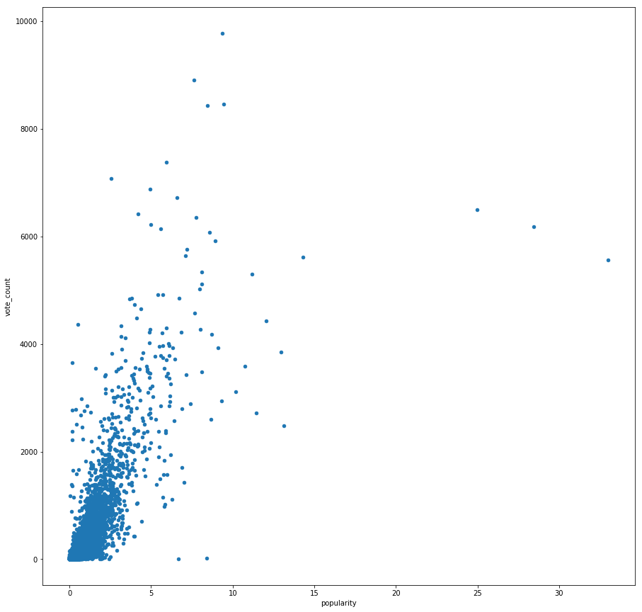

```python
df.plot(x='popularity', y='vote_count', kind='scatter', figsize=(15, 15));
```

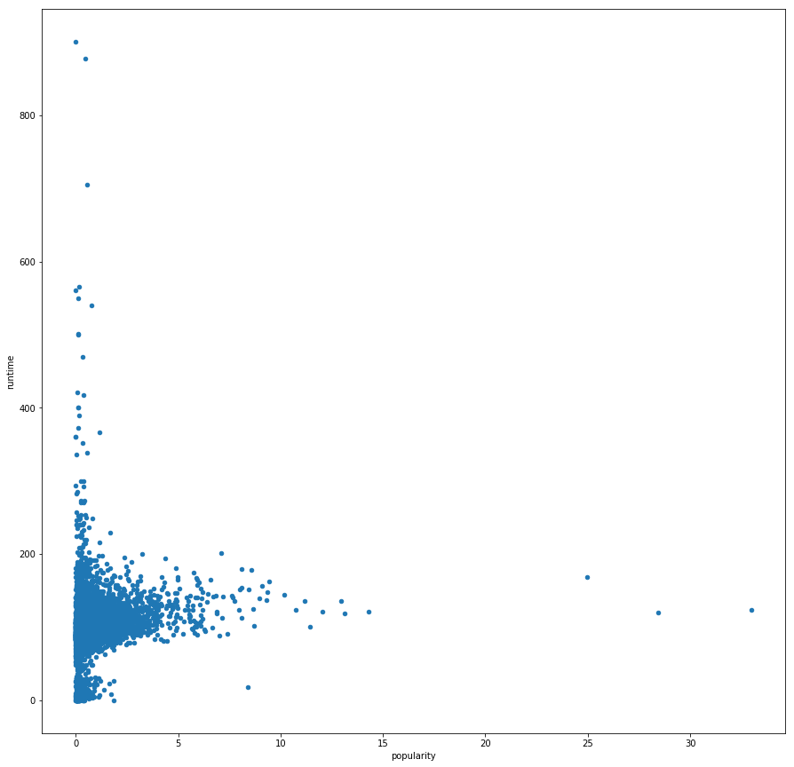

```python
df.plot(x='popularity', y='runtime', kind='scatter', figsize=(15, 15));
```

> we can say that the popularity of a movie is high when the runtime is between 100-150 minutes

## Conclusions

> Now we will answer the questions given below :

[output not shown]

> NOTE: no help was taken from any outside source.